# Business Analytics Assignment 3

Raju Rishikesh Gollapally

2023-11-04

#Question 1:

Run the following code in R-studio to create two variables X and Y.

```r
set.seed(2017)
X=runif(100)*10
Y=X*4+3.45
Y=rnorm(100)*0.29*Y+Y
```

1(a): Plot Y against X. Include a screenshot of the plot in your submission. Using the File menu you can save the graph as a picture on your computer. Based on the plot do you think we can fit a linear model to explain Y based on X?

#Scatterplot

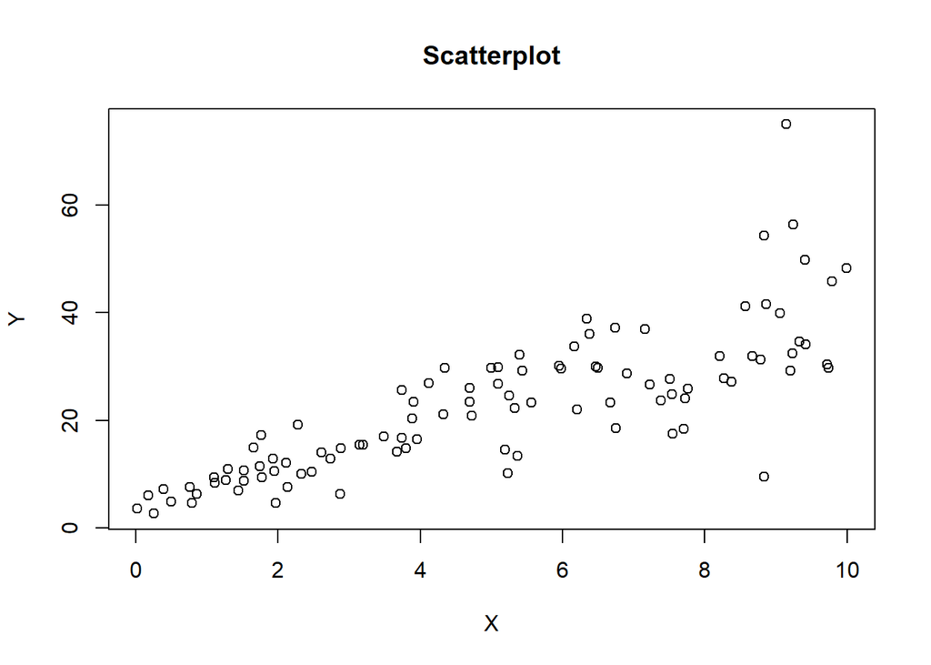

```r
plot(X,Y, main = "Scatterplot")  #The scatter plot's creation
```

# I believe the figure, which shows a steady increase in Y with a change in X, matches the linear model for the provided values. It demonstrates a satisfying partnership.

1(B)Construct a simple linear model of Y based on X. Write the equation that explains Y based on X. What is the accuracy of this model?

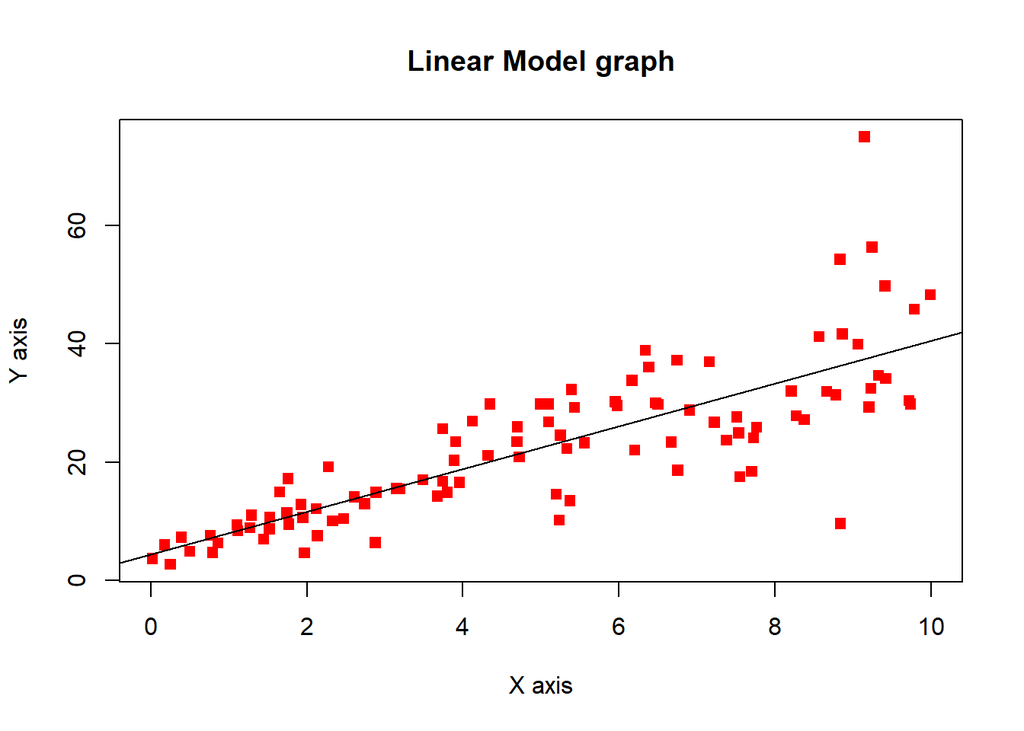

```r
plot(X,Y,xlim = c(0,10), xlab = "X axis",ylab = "Y axis", main = "Linear Model graph", col = "red", pch=15)
abline(lsfit(X,Y),col = "black")
```

```r
model_newly =lm(Y~X)  #Equation Model
summary(model_newly)
```

```
##
## Call:
## lm(formula = Y ~ X)
##
## Residuals:
##     Min      1Q  Median      3Q     Max
## -26.755  -3.846  -0.387   4.318  37.503
##
## Coefficients:
##             Estimate Std. Error t value Pr(>|t|)
## (Intercept)   4.4655     1.5537   2.874  0.00497 **
## X             3.6108     0.2666  13.542  < 2e-16 ***
## ---
## Signif. codes:  0 '***' 0.001 '**' 0.01 '*' 0.05 '.' 0.1 ' ' 1
##
## Residual standard error: 7.756 on 98 degrees of freedom
## Multiple R-squared:  0.6517, Adjusted R-squared:  0.6482
## F-statistic: 183.4 on 1 and 98 DF,  p-value: < 2.2e-16
```

# Y=4.465 + 3.611*X is the regression equation that defines Y in terms of X. The model’s accuracy was found to be 65%.

1(c): How the Coefficient of Determination, R 2, of the model above is related to the correlation coefficient of X and Y?

```r
R2 <- cor(X,Y)^2   # The process of determining coefficient
R2
```

```
## [1] 0.6517187
```

# A significant correlation between X and Y is shown by the R2 of 65% between X and Y, which is produced using the cor(X,Y)^2 and the Coefficient of Determination of 65% of the preceding solved model that we received from summary.

#Question 2:

We will use the ‘mtcars’ dataset for this question. The dataset is already included in your R distribution. The dataset shows some of the characteristics of different cars. The following shows few samples (i.e. the first 6 rows) of the dataset.

This is the head of mtcars:

```r
head(mtcars)   # illustrating the initial few values
```

|  | mpg | cyl | disp | hp | drat | wt | qsec | vs | am | gear | carb |
| --- | --- | --- | --- | --- | --- | --- | --- | --- | --- | --- | --- |
| Mazda RX4 | 21.0 | 6 | 160 | 110 | 3.90 | 2.620 | 16.46 | 0 | 1 | 4 | 4 |
| Mazda RX4 Wag | 21.0 | 6 | 160 | 110 | 3.90 | 2.875 | 17.02 | 0 | 1 | 4 | 4 |
| Datsun 710 | 22.8 | 4 | 108 | 93 | 3.85 | 2.320 | 18.61 | 1 | 1 | 4 | 1 |
| Hornet 4 Drive | 21.4 | 6 | 258 | 110 | 3.08 | 3.215 | 19.44 | 1 | 0 | 3 | 1 |
| Hornet Sportabout | 18.7 | 8 | 360 | 175 | 3.15 | 3.440 | 17.02 | 0 | 0 | 3 | 2 |
| Valiant | 18.1 | 6 | 225 | 105 | 2.76 | 3.460 | 20.22 | 1 | 0 | 3 | 1 |

2(A) James wants to buy a car. He and his friend, Chris, have different opinions about the Horse Power (hp) of cars. James think the weight of a car (wt) can be used to estimate the Horse Power of the car while Chris thinks the fuel consumption expressed in Mile Per Gallon (mpg), is a better estimator of the (hp). Who do you think is right? Construct simple linear models using mtcars data to answer the question.

```r
# James's viewpoint about automobile horsepower

James_view <- lm(mtcars$hp ~ mtcars$wt, data = mtcars)
summary(James_view)
```

```
##
## Call:
## lm(formula = mtcars$hp ~ mtcars$wt, data = mtcars)
##
## Residuals:
##     Min      1Q  Median      3Q     Max
## -83.430 -33.596 -13.587   7.913 172.030
##
## Coefficients:
##             Estimate Std. Error t value Pr(>|t|)
## (Intercept)   -1.821     32.325  -0.056    0.955
## mtcars$wt     46.160      9.625   4.796 4.15e-05 ***
## ---
## Signif. codes:  0 '***' 0.001 '**' 0.01 '*' 0.05 '.' 0.1 ' ' 1
##
## Residual standard error: 52.44 on 30 degrees of freedom
## Multiple R-squared:  0.4339, Adjusted R-squared:  0.4151
## F-statistic:    23 on 1 and 30 DF,  p-value: 4.146e-05
```

```r
# Chris's viewpoint about automobile horsepower

Chris_view <- lm(mtcars$hp ~ mtcars$mpg, data = mtcars)
summary(Chris_view)
```

```
##
## Call:
## lm(formula = mtcars$hp ~ mtcars$mpg, data = mtcars)
##
## Residuals:
##    Min     1Q Median     3Q    Max
## -59.26 -28.93 -13.45  25.65 143.36
##
## Coefficients:
##             Estimate Std. Error t value Pr(>|t|)
## (Intercept)   324.08      27.43  11.813 8.25e-13 ***
## mtcars$mpg     -8.83       1.31  -6.742 1.79e-07 ***
## ---
## Signif. codes:  0 '***' 0.001 '**' 0.01 '*' 0.05 '.' 0.1 ' ' 1
##
## Residual standard error: 43.95 on 30 degrees of freedom
## Multiple R-squared:  0.6024, Adjusted R-squared:  0.5892
## F-statistic: 45.46 on 1 and 30 DF,  p-value: 1.788e-07
```

# Given that Chris’s perspective has a 60% rate of coefficient compared to James’s 43%, it is significantly more important that the miles per gallon dictate horse power rather than weight.

2(b):

Build a model that uses the number of cylinders (cyl) and the mile per gallon (mpg) values of a car to predict the car Horse Power (hp). Using this model, what is the estimated Horse Power of a car with 4 calendar and mpg of 22?

```r
horse_powr <- lm(hp ~ cyl + mpg,data = mtcars )
summary(horse_powr)
```

```
##
## Call:
## lm(formula = hp ~ cyl + mpg, data = mtcars)
##
## Residuals:
##    Min     1Q Median     3Q    Max
## -53.72 -22.18 -10.13  14.47 130.73
##
## Coefficients:
##             Estimate Std. Error t value Pr(>|t|)
## (Intercept)   54.067     86.093   0.628  0.53492
## cyl           23.979      7.346   3.264  0.00281 **
## mpg           -2.775      2.177  -1.275  0.21253
## ---
## Signif. codes:  0 '***' 0.001 '**' 0.01 '*' 0.05 '.' 0.1 ' ' 1
##
## Residual standard error: 38.22 on 29 degrees of freedom
## Multiple R-squared:  0.7093, Adjusted R-squared:  0.6892
## F-statistic: 35.37 on 2 and 29 DF,  p-value: 1.663e-08
```

```r
predict(horse_powr, data.frame(cyl = 4,mpg=22))  # Expectation/Perdiction
```

```
##        1
## 88.93618
```

Horse Power: 88.936

```r
horse_powr <- lm(mtcars$hp ~ mtcars$mpg + mtcars$cyl,data = mtcars )
summary(horse_powr)
```

```
##
## Call:
## lm(formula = mtcars$hp ~ mtcars$mpg + mtcars$cyl, data = mtcars)
##
## Residuals:
##    Min     1Q Median     3Q    Max
## -53.72 -22.18 -10.13  14.47 130.73
##
## Coefficients:
##             Estimate Std. Error t value Pr(>|t|)
## (Intercept)   54.067     86.093   0.628  0.53492
## mtcars$mpg    -2.775      2.177  -1.275  0.21253
## mtcars$cyl    23.979      7.346   3.264  0.00281 **
## ---
## Signif. codes:  0 '***' 0.001 '**' 0.01 '*' 0.05 '.' 0.1 ' ' 1
##
## Residual standard error: 38.22 on 29 degrees of freedom
## Multiple R-squared:  0.7093, Adjusted R-squared:  0.6892
## F-statistic: 35.37 on 2 and 29 DF,  p-value: 1.663e-08
```

```r
horse_powr$coefficients
```

```
## (Intercept)  mtcars$mpg  mtcars$cyl
##   54.066600   -2.774769   23.978626
```

```r
predict_horse_powr <- (horse_powr$coefficients[2]*22) + (horse_powr$coefficients[3]*4)
predict_horse_powr
```

```
## mtcars$mpg
##   34.86958
```

#Question 3:

For this question, we are going to use BostonHousing dataset. The dataset is in ‘mlbench’ package, so we first need to instal the package, call the library and the load the dataset using the following commands

installing the mlbench package and utilizing library(mlbench) to execute code

```r
# install.packages('mlbench')
library(mlbench)
data(BostonHousing)
```

#printing Boston Housing’s initial few rows

```r
head(BostonHousing) # First few rows of Boston Housing
```

|  | crim | zn | indus | chas | nox | rm | age | dis | rad | tax | ptratio | b | lstat | medv |
| --- | --- | --- | --- | --- | --- | --- | --- | --- | --- | --- | --- | --- | --- | --- |
| 1 | 0.00632 | 18 | 2.31 | 0 | 0.538 | 6.575 | 65.2 | 4.0900 | 1 | 296 | 15.3 | 396.90 | 4.98 | 24.0 |
| 2 | 0.02731 | 0 | 7.07 | 0 | 0.469 | 6.421 | 78.9 | 4.9671 | 2 | 242 | 17.8 | 396.90 | 9.14 | 21.6 |
| 3 | 0.02729 | 0 | 7.07 | 0 | 0.469 | 7.185 | 61.1 | 4.9671 | 2 | 242 | 17.8 | 392.83 | 4.03 | 34.7 |
| 4 | 0.03237 | 0 | 2.18 | 0 | 0.458 | 6.998 | 45.8 | 6.0622 | 3 | 222 | 18.7 | 394.63 | 2.94 | 33.4 |
| 5 | 0.06905 | 0 | 2.18 | 0 | 0.458 | 7.147 | 54.2 | 6.0622 | 3 | 222 | 18.7 | 396.90 | 5.33 | 36.2 |
| 6 | 0.02985 | 0 | 2.18 | 0 | 0.458 | 6.430 | 58.7 | 6.0622 | 3 | 222 | 18.7 | 394.12 | 5.21 | 28.7 |

3(a):

Build a model to estimate the median value of owner-occupied homes (medv)based on the following variables: crime crate (crim), proportion of residential land zoned for lots over 25,000 sq.ft (zn), the local pupil-teacher ratio (ptratio) and weather the whether the tract bounds Chas River(chas). Is this an accurate model?

```r
Bost_Housing_Newly <- lm(formula = BostonHousing$medv ~ BostonHousing$crim + BostonHousing$zn + BostonHousing$ptrat + BostonHousing$chas)

summary(Bost_Housing_Newly)
```

```
##
## Call:
## lm(formula = BostonHousing$medv ~ BostonHousing$crim + BostonHousing$zn +
##     BostonHousing$ptrat + BostonHousing$chas)
##
## Residuals:
##     Min      1Q  Median      3Q     Max
## -18.282  -4.505  -0.986   2.650  32.656
##
## Coefficients:
##                     Estimate Std. Error t value Pr(>|t|)
## (Intercept)         49.91868    3.23497  15.431  < 2e-16 ***
## BostonHousing$crim  -0.26018    0.04015  -6.480 2.20e-10 ***
## BostonHousing$zn     0.07073    0.01548   4.570 6.14e-06 ***
## BostonHousing$ptrat -1.49367    0.17144  -8.712  < 2e-16 ***
## BostonHousing$chas1  4.58393    1.31108   3.496 0.000514 ***
## ---
## Signif. codes:  0 '***' 0.001 '**' 0.01 '*' 0.05 '.' 0.1 ' ' 1
##
## Residual standard error: 7.388 on 501 degrees of freedom
## Multiple R-squared:  0.3599, Adjusted R-squared:  0.3547
## F-statistic: 70.41 on 4 and 501 DF,  p-value: < 2.2e-16
```

#Here, the Rate of Coefficient is 36%, which is extremely low, leading us to conclude that the model is not reliable.

3(b) |.Imagine two houses that are identical in all aspects but one bounds the Chas River and the other does not. Which one is more expensive and by how much?

```r
Bost_House <- lm(formula = BostonHousing$medv ~ BostonHousing$chas, data = BostonHousing)
```

```r
Residence_1 <- Bost_House$coefficients[1] + Bost_House$coefficients[2]*0
Residence_2 <- Bost_House$coefficients[1] + Bost_House$coefficients[2]*1
Cost <- Residence_2 - Residence_1
Cost
```

```
## (Intercept)
##    6.346157
```

# The Chas River-front Residence costs 6.346157 more than the other one.

3(b) ||.Imagine two houses that are identical in all aspects but in the neighborhood of one of them the pupil-teacher ratio is 15 and in the other one is 18. Which one is more expensive and by how much?

```r
Bost_House_case2 <- lm(formula = BostonHousing$medv ~ BostonHousing$ptratio, data = BostonHousing)
Bost_House_case2
```

```
##
## Call:
## lm(formula = BostonHousing$medv ~ BostonHousing$ptratio, data = BostonHousing)
##
## Coefficients:
##           (Intercept)  BostonHousing$ptratio
##                62.345                 -2.157
```

```r
Residence_a <- Bost_House_case2$coefficients[1] + Bost_House_case2$coefficients[2] * 15
Residence_b <- Bost_House_case2$coefficients[1] + Bost_House_case2$coefficients[2] * 18

Cost_recently <- Residence_a - Residence_b
Cost_recently
```

```
## (Intercept)
##    6.471526
```

3(c): Which of the variables are statistically important (i.e. related to the house price)? Hint: use the p-values of the coefficients to answer.

```r
summary(Bost_Housing_Newly)
```

```
##
## Call:
## lm(formula = BostonHousing$medv ~ BostonHousing$crim + BostonHousing$zn +
##     BostonHousing$ptrat + BostonHousing$chas)
##
## Residuals:
##     Min      1Q  Median      3Q     Max
## -18.282  -4.505  -0.986   2.650  32.656
##
## Coefficients:
##                     Estimate Std. Error t value Pr(>|t|)
## (Intercept)         49.91868    3.23497  15.431  < 2e-16 ***
## BostonHousing$crim  -0.26018    0.04015  -6.480 2.20e-10 ***
## BostonHousing$zn     0.07073    0.01548   4.570 6.14e-06 ***
## BostonHousing$ptrat -1.49367    0.17144  -8.712  < 2e-16 ***
## BostonHousing$chas1  4.58393    1.31108   3.496 0.000514 ***
## ---
## Signif. codes:  0 '***' 0.001 '**' 0.01 '*' 0.05 '.' 0.1 ' ' 1
##
## Residual standard error: 7.388 on 501 degrees of freedom
## Multiple R-squared:  0.3599, Adjusted R-squared:  0.3547
## F-statistic: 70.41 on 4 and 501 DF,  p-value: < 2.2e-16
```

#Based on the summary overall p-value of less than 2.2e-16, or less than 5%, we may conclude that the variables are statistically significant.

3(d): Use the anova analysis and determine the order of importance of these four variables.

```r
Ord_Impt <- anova(Bost_Housing_Newly)  # Order of Importance
Ord_Impt
```

|  | Df | Sum Sq | Mean Sq | F value | Pr(>F) |
| --- | --- | --- | --- | --- | --- |
| BostonHousing$crim | 1 | 6440.7831 | 6440.78306 | 118.00683 | 7.902220e-25 |
| BostonHousing$zn | 1 | 3554.3362 | 3554.33620 | 65.12189 | 5.252886e-15 |
| BostonHousing$ptrat | 1 | 4709.5358 | 4709.53584 | 86.28724 | 4.738745e-19 |
| BostonHousing$chas | 1 | 667.1868 | 667.18681 | 12.22407 | 5.136898e-04 |
| Residuals | 501 | 27344.4535 | 54.57975 | NA | NA |